# X2 test dobré shody a nezávislosti

Klíčove pojmy:

- chikvadrat rozložení
- chikvadrat test dobré shody
- chikvadrat test nezávislosti

### Chikvadrat rozložení

Chikvadrát rozložení ($\chi^2(k)$) je pravděpodobnostní rozložení, které má jediný parameter, počet stupňů volnosti $k$. Např. součet pozorování, které pocházejí z normálního rozložení nabývají $\chi^2$ rozložení. Tyto pozorování jsou umocněny na 2. Pojďme si tuto skutečnost ukázat.

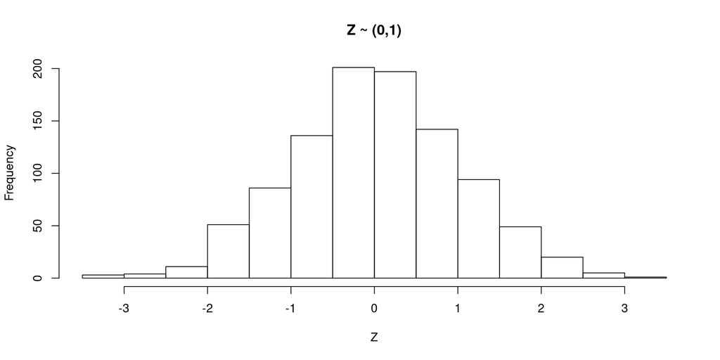

```r
z <- rnorm(1000)
hist(z, breaks = 10, main = "Z ~ (0,1)", xlab = "Z")
```

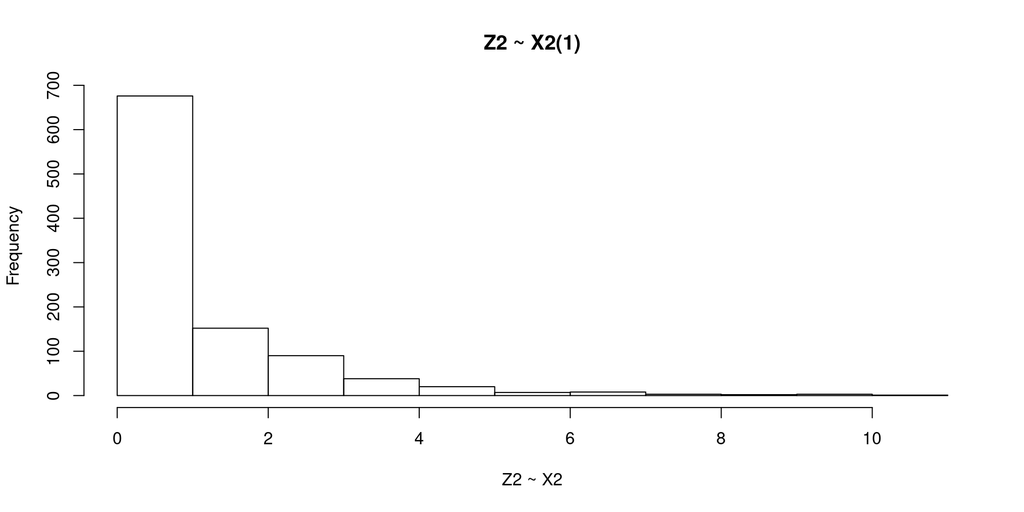

```r
chi2 <- z^2
hist(chi2, breaks = 10, main = "Z2 ~ X2(1)", xlab = "Z2 ~ X2")
```

V `R` můžeme použít známé funkce pravděpodobnostního rozložení, pro $\chi^2$ použijeme název `chisq`. Pojďme si ukázat, jak vyvořit hustotu pravděpodobnosti a další operace s pravděpodobnostním rozložení, které jsme dělali s normálním, binomickým a studentovým rozložením. Jak jsme viděli nahoře $\chi^2$ rozložení má pouze kladné hodnoty.

```r
# hustota pravdepodobnosti
X <- seq(0, 15, by = 0.001)
k <- 2
pdf <- dchisq(X, df = k)
plot(X, pdf,
     type = "l",
     xlab = "X", ylab = "f(X)", main = "X2(2)")

# distribucni funkce
cdf <- 1-pchisq(5, df = k)
print(paste0("Pravděpodobnost, že x pocházející z X2 rozložení s ", k, " stupni volsnoti, bude > 5 je ", round(cdf, 2)))
```

```
## [1] "Pravděpodobnost, že x pocházející z X2 rozložení s 2 stupni volsnoti, bude > 5 je 0.08"
```

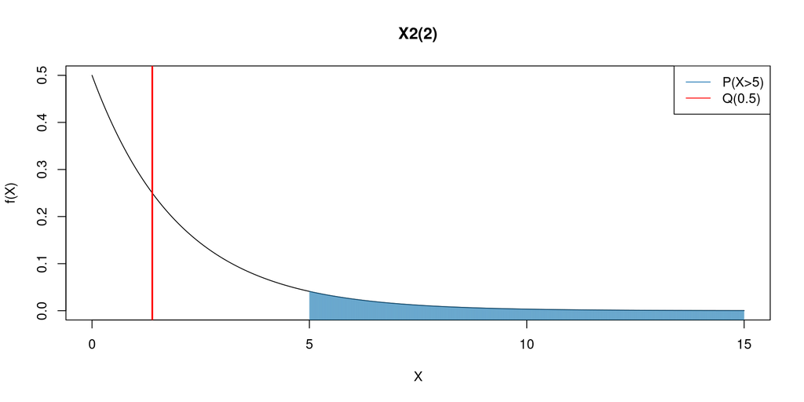

```r
# na grafu bychom to zobrazili jako
for(i in c(1:length(X))) {
  if(X[i] > 5) {
    lines(c(X[i], X[i]), c(-1, pdf[i]), col = adjustcolor("#1f77b4", alpha.f = 0.05))
  }
}

# kvantil X2 rozlozeni zjistime takto
## takto bychom napriklad mohli zjistit median
x <- qchisq(0.5, df = k)
# a pridame do grafu
abline(v = x, col= "red", lwd = 2)
legend("topright", legend = c("P(X>5)", "Q(0.5)"), lty = c(1,1), col = c("#1f77b4", "red"))
```

### Test dobré shody

Tento test používáme, pokud chceme porovnat více výběrových relativních četností s teoretickými relativními četnostmi. Tedy, $H_0: F(x) = F_0(x)$ a $H_1: F(x) \ne F_0(x)$. Testovací statistika $\chi^2$ se vypočítá jako $\chi^2 = \sum_{i=1}^k\frac{(n_i - np_i)^2}{np_i}$, kde $n_i$ jsou pozorované četnosti pro danou kategorii a $np_i$ je očekávaná četnost za předpokladu $H_0$ a $k$ je počet kategorií. Tato testovací statistika má $\chi^2$ rozložení s $k-1$ stupni volnosti. Pojďme si ukázat testo test na příkladu hodu kostkou. Ze série vyrobených kostek byla náhodou vybána jedna kostka a bylo provedeno 60 hodů. Máme rozhodnout, zda jsou kostky z této série pravidelné.

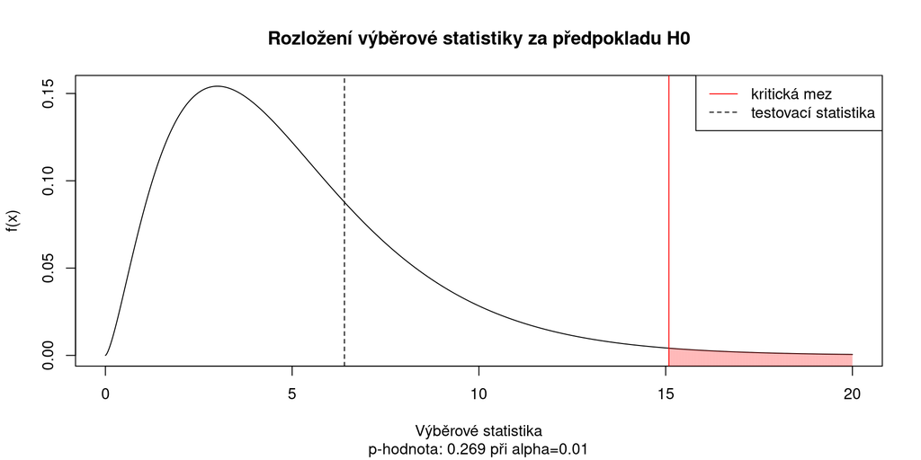

```r
# nase hody
hody <- c(9,12,7,5,14,13)
n <- sum(hody)
# H0: F(x) = F_0(x)
# H1: F(x) != F_0(x)

# p za predpokladu H0
p_0 <- rep(1/6)

# testovaci statistika
chi2 <- sum((hody - n*p_0)^2 / (n*p_0))
s_v <- length(hody) - 1
alpha <- 0.01
kriticka_mez <- qchisq(1-alpha, df = s_v)

# zobrazime
x <- seq(0, 20, 0.001)
pdf <- dchisq(x, df = s_v)
p <- 1-pchisq(chi2, df = s_v)


plot(x, pdf,
     xlab = "Výběrové statistika", ylab = "f(x)",
     main = "Rozložení výběrové statistiky za předpokladu H0",
     sub = paste0("p-hodnota: ", round(p, 3), " při alpha=", alpha),
     type = "l")
abline(v = kriticka_mez, col = "red")
# oblast zamitnuti H0
for(i in c(1:length(x))) {
  if(x[i] > kriticka_mez) {
    lines(c(x[i], x[i]), c(-1, pdf[i]),
          col = adjustcolor("red", alpha.f = 0.01))
  }
}
abline(v = chi2, lty = 2)
legend("topright",
       c("kritická mez", "testovací statistika"),
       col = c("red", "black"),
       lty = c(1,2))
```

```r
# tedy nezamitame H0 ve prospech H1, kostka je pravidelna
```

Stejně bychom toho mohli dosáhnout pomocí funkce `chisq.test`.

```r
chisq.test(x = hody, p = rep(p_0, 6))
```

```
##
##  Chi-squared test for given probabilities
##
## data:  hody
## X-squared = 6.4, df = 5, p-value = 0.2692
```

### Chikvadrát test nezávislosti

Tento test použijeme, pokud máme dvě proměnné (například $x$ a $y$), která nám tvoří kontingenční tabulku a zajímá nás, zda spolu tyto proměnné souvisí (jsou na sobě závislé). Nulová hypotéza je, že $x$ a $y$ na sobě nejsou závislé a alternativní, že $x$ a $y$ na sobě závislé jsou, tedy $H_0: x \!\perp\!\!\!\perp y$ a $H_1: x \not\!\perp\!\!\!\perp y$. Testovací statistiku opět vypočítáme jako $\chi^2 = \sum_{i=1}^k\frac{(O_i - E_i)^2}{E_i}$, kde $O_i$ značí pozorované četnosti v dané buňce kontingenční tabulky a $E_i$ očekávané četnosti za předpokladu $H_0$. Očekávané četnosti pro danou buňku kontingenční tabulky můžeme vypočítat jako součet hodnot v řádku buňky * součet hodnot v sloupci buňky vydělené celkovým počtem pozorování ve všech buňkách. Tato testovací statistika nabývá $\chi^2$ rozložení s $k_x - 1 * k_y -1$ stupni volnosti. Pojďme si tento test ukázat na následujícím příkladu. Máme kontrolní (`0`) a experimentální skupinu (`1`). Experimentální skupině byla podána vakcína. Po nějaké době změříme u obou skupin počet lidí s danou nemocí (`0` pokud nemoc jedinec neprodělal a `1` pokud prodělal). Zajímá nás, zda existuje souvislost mezi podáním vakcíny a výskytem nemoci.

```r
# nacteme data
vaccine <- read.csv("https://raw.githubusercontent.com/schubertjan/cuni/master/stats/data/vaccine.csv")

# pomoci xtabs muzeme vytvorit kontingencni tabulku
t_o <- xtabs( ~ group + disease, data = vaccine)
print(t_o)
```

```
##      disease
## group     0     1
##     0 21683    86
##     1 21761     8
```

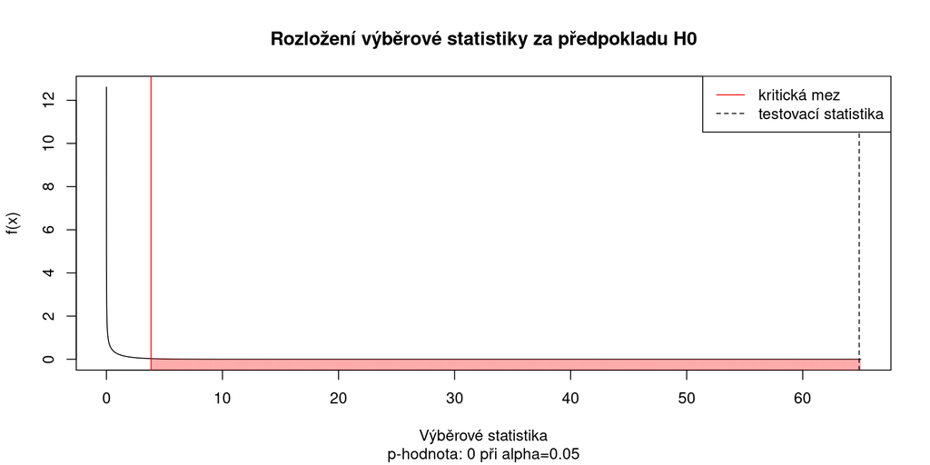

```r
# H0: neexistuje souvislost mezi podanim vakciny a vyskytem nemoci
# H1: existuje souvislost mezi podanim vakciny a vyskytem nemoci

# nyni vypocitame ocekavane cetnosti za predpokladu H0 (tedy nezavislosti mezi promennymi)
t_e <- t_o # zkopirujeme si t_o, abychom nemuseli vytvařet objekt o stejnem poctu radku a sloupcu
## vypocitame ocekavane cetnosti podle postupu popsanem v textu nahore
t_e[1,1] <- sum(t_o[1, ]) * sum(t_o[, 1]) / sum(t_o)
t_e[1,2] <- sum(t_o[1, ]) * sum(t_o[, 2]) / sum(t_o)
t_e[2,1] <- sum(t_o[2, ]) * sum(t_o[, 1]) / sum(t_o)
t_e[2,2] <- sum(t_o[2, ]) * sum(t_o[, 2]) / sum(t_o)

# vypocitame testovaci statistiku
chi2 <- sum((t_o - t_e)^2 / t_e)
s_v <- (nrow(t_e) - 1) *  (ncol(t_e) - 1)
alpha <- 0.05
kriticka_mez <- qchisq(1-alpha, df = s_v)

# vytvorime graf za predpokladu H0
x <- seq(0, 65, 0.001)
pdf <- dchisq(x, df = s_v)
p <- 1-pchisq(chi2, df = s_v)

plot(x, pdf,
     xlab = "Výběrové statistika", ylab = "f(x)",
     main = "Rozložení výběrové statistiky za předpokladu H0",
     sub = paste0("p-hodnota: ", round(p, 3), " při alpha=", alpha),
     type = "l")
abline(v = kriticka_mez, col = "red")
# oblast zamitnuti H0
for(i in c(1:length(x))) {
  if(x[i] > kriticka_mez) {
    lines(c(x[i], x[i]), c(-1, pdf[i]),
          col = adjustcolor("red", alpha.f = 0.005))
  }
}
abline(v = chi2, lty = 2)
legend("topright",
       c("kritická mez", "testovací statistika"),
       col = c("red", "black"),
       lty = c(1,2))
```

Stejně tak, bychom mohli použít funkci `chisq.test`.

```r
chi2_test <- chisq.test(t_o, correct = FALSE)
chi2_test
```

```
##
##  Pearson's Chi-squared test
##
## data:  t_o
## X-squared = 64.863, df = 1, p-value = 8.027e-16
```

```r
# ocekavane cetnosti muzeme extraktovat pomoci chi2_test$expected
```